# DV Assignment 2, Part 1: Effects of school disadvantage heterogeneity

Group 3: Filip Hlavinka, Henning Lang

2026-10-04

## **Research question and audience**

Introduction

We have decided to look at how spreiding (within-school variance of disadvantage) could affect test scores/final school advise across different levels of schoolweging (mean school disadvantage). We thought this would be interesting to see if more heterogeneous groups with regard to advantaged/disadvantaged backgrounds (based on parental income and education) could be related to better performance. There is some evidence to suggest that the performance of students can benefit in more heterogeneous social environments, so we thought it would be interesting to analyze if we could observe a similar phenomenon in this data. We made several exploratory plots included in our test scripts folders but decided to keep only a couple of those here for simplicity. At this point, the question is analytical, so we just look at the visualizations to see if there are any discernible patterns which we could later model. The audience could be policymakers and school boards, but given the severe limitations of what we are measuring, a certain level of nuance and expertise is required when interpreting the data.

Short summary

[output not shown]

## **Exploratory plots**

**Plot 1**

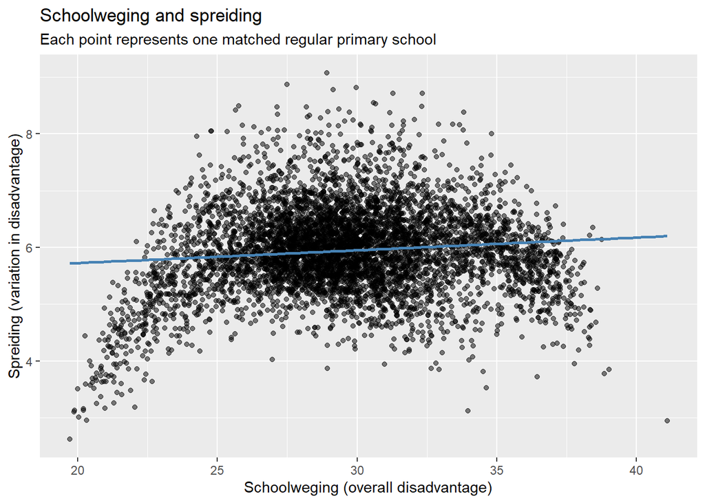

Description

The above graph visualizes the variance of disadvantage within school (y-axis) and different levels of overall disadvantage of the school (x-axis). Each point represents an individual institution. After seeing this, we thought it would be interesting to then see if schools in roughly the same schoolweging would have different performance scores depending on their spreiding.

**Plot 2**

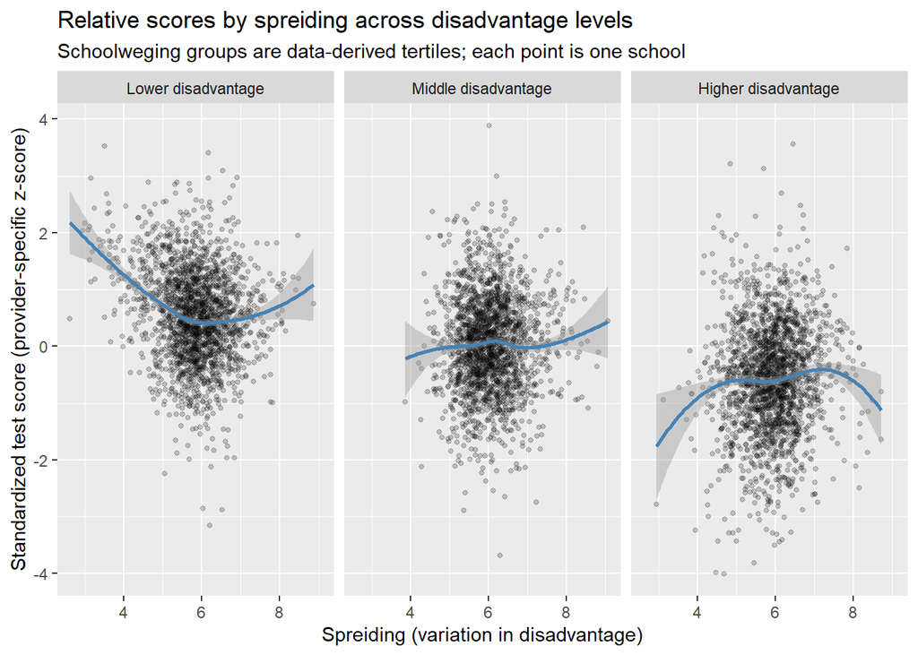

Description

The above graph uses standardized test scores (as schools use different providers) to see if student performance is higher with high or low variance of disadvantage. This is done for three levels of overall disadvantage: Low, Mid, and High. There doesn’t seem to be any apparent trend in the relationship we expected. However, we can also see that, overall, students with higher disadvantage also have overall worse performance.

**Plot 3**

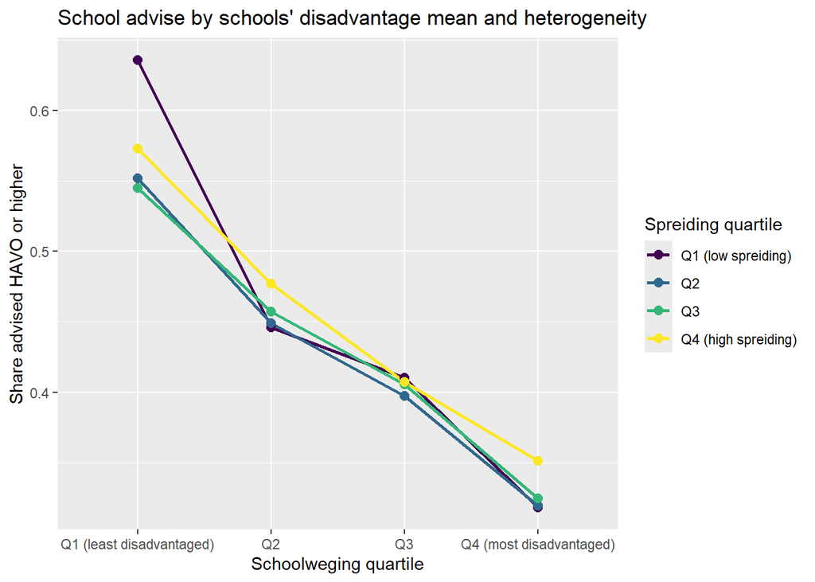

Description

Additionally, we performed the same analysis, but instead of standardized scores, we used the share of students advised to HAVO or higher as outcome (i. e. the final school advise). We used schoolweging quartiles on the x-axis and the spreiding-quartiles as lines in different colours. The graph shows that given the particular effect of schoolweging there is no relevant additional effect of within-school disadvantage heterogeneity.

**Plot 4**

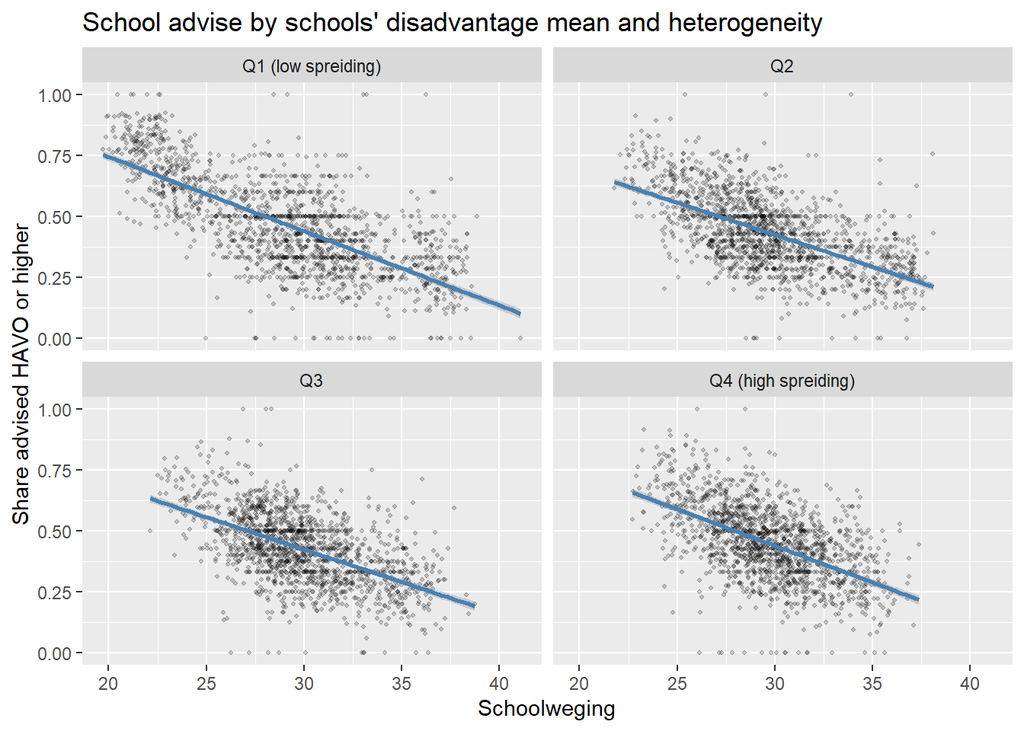

Description

In this plot again the share of students advised to HAVO or higher was the considered outcome. The plots are also this time split according to within-school disadvantage variance rather than overall variance, as it was the case above. These visualizations seem to follow the same pattern: there seems to be no aditional effect of spreiding, but definitely an effect of schoolweging.

## **Feedback**

We’d appreciate your **feedback on the second plot**. Thanks!

## **Link to our GitHub repository**

https://github.com/HenningLa7/bds_toolbox_data_viz_group3